# Generating correlation matrix

Here I will explain how to use the functions

```r
generateCorrelationMatrix(M,type,alphad=0.5,phi=0.5,sparse=F,thres=1e-4, delta = rep(1,M) )
generateCoVarianceMatrix(corMatrix, sigmas =  rep(1,ncol(corMatrix)))
```

# Examples

Here alphad is equal to 100, that means low correlation between variables

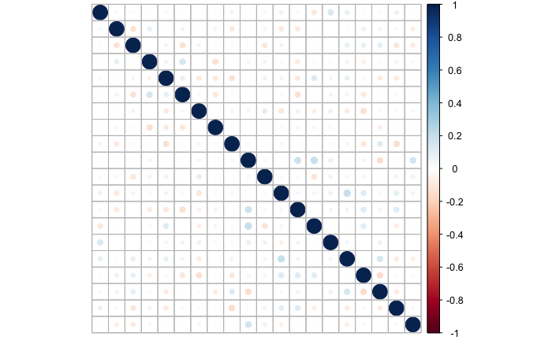

```r
require(corrplot)
source('./generateCorrelation.R')
corrplot(generateCorrelationMatrix(20,"random",alphad=100),tl.pos = "n")
```

Here alphad equals 0.001 that means high correlation between variables

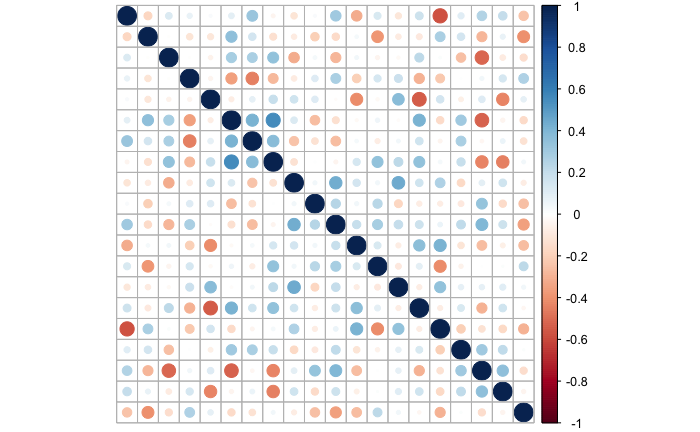

```r
corrplot(generateCorrelationMatrix(20,"random",alphad=0.001),tl.pos = "n")
```

Now we generate an AR(1) correlation matrix

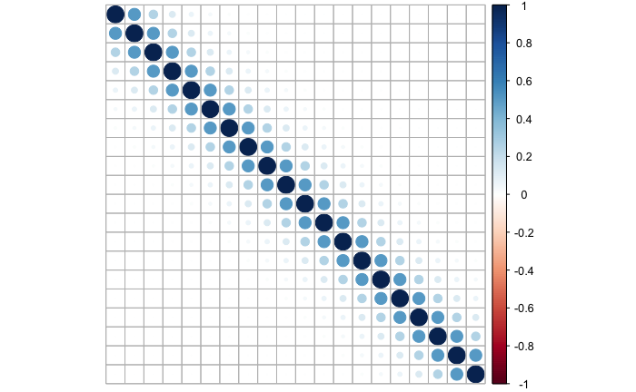

```r
corrplot(generateCorrelationMatrix(20,"AR"),tl.pos = "n")
```

We change phi to have more correlation

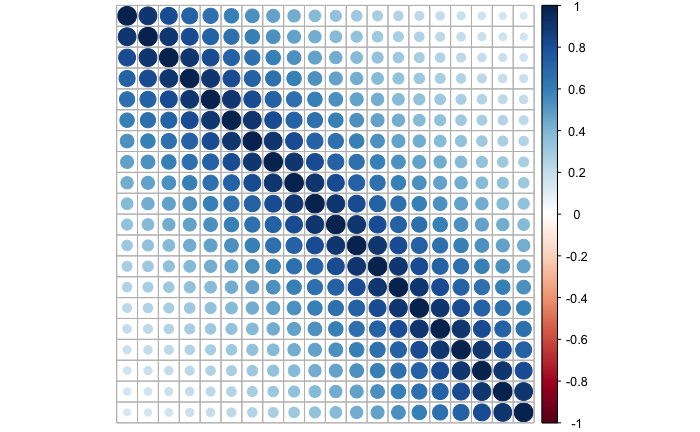

```r
corrplot(generateCorrelationMatrix(20,"AR",phi = 0.9),tl.pos = "n")
```

We can also induce a block structure in the AR model by interwinding some delta > 1 at some points

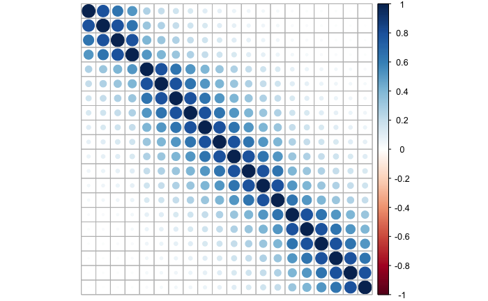

```r
block_delta <- c(rep(1,4),3,rep(1,9),2,rep(1,5)) # now you have steps of size 3 at pos. 5, and 2 at pos.15
corrplot(generateCorrelationMatrix(20,"AR",phi=0.8 ,delta=block_delta),tl.pos = "n")
```

## Generating covariates

First we can generate a Covariance matrix from the correlation matrix, we can set the vector of standard deviations or use the default value of 1 for all covariates

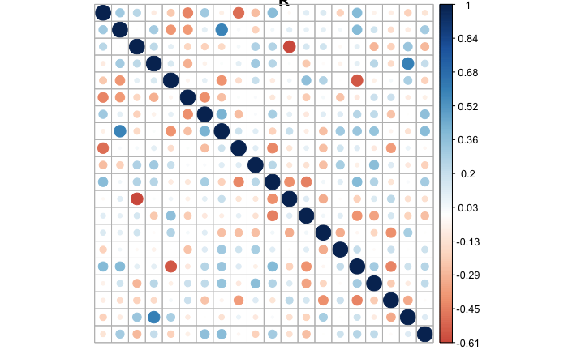

```r
R <- generateCorrelationMatrix(20,"random",alphad=0.001)
Sigma <- generateCoVarianceMatrix(R)
corrplot(R,is.corr = F,tl.pos = "n",title = "R")
```

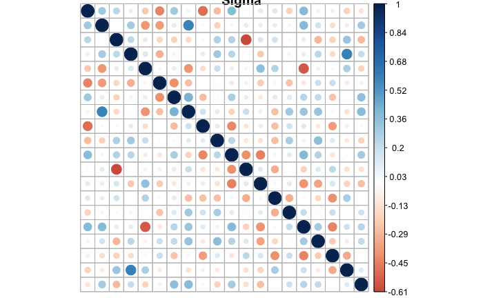

```r
corrplot(Sigma,is.corr = F,tl.pos = "n",title = "Sigma")
```

Now we can generate a set of covariates by drawing N samples from a multivariate normal, thus having our design matrix $X$

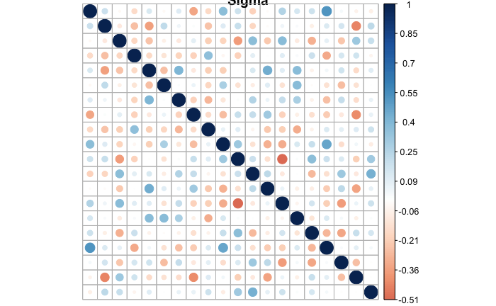

```r
require(MASS)
M <- 20
N <- 10
R <- generateCorrelationMatrix(M,"random",alphad=0.001)
Sigma <- generateCoVarianceMatrix(R)
X <- mvrnorm(n = N, rep(0,M), Sigma)
corrplot(Sigma,is.corr = F, tl.pos = F, title = "Sigma")
```

We are going to plot the scatter matrix $X^tX/N$ for different sample sizes, and scaled and unscaled values

```r
par(mfrow=c(2,2))
corrplot( t(X) %*% X/N, is.corr=F, tl.pos =F, title = "un-scaled N=10")
corrplot( t(scale(X)) %*% scale(X)/N, is.corr=F, tl.pos =F, title = "scaled N=10")
```

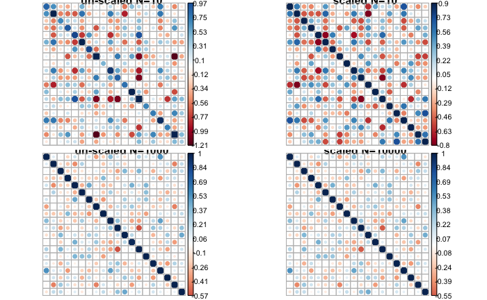

```r
N<-1000
X <- mvrnorm(n = N, rep(0,M), Sigma)
corrplot( t(X) %*% X/N, is.corr=F, tl.pos =F, title ="un-scaled N=1000")
corrplot( t(scale(X)) %*% scale(X)/N, is.corr=F, tl.pos =F, title = "scaled N=10000")
```

Now for an AR(1) process

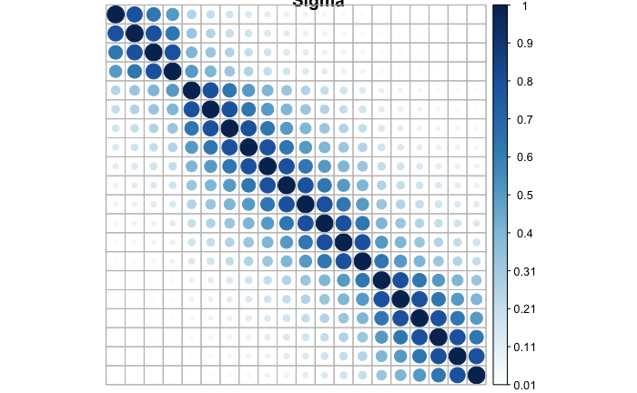

```r
M <- 20
N <- 10
block_delta <- c(rep(1,4),3,rep(1,9),2,rep(1,5))
R <- generateCorrelationMatrix(M,"AR",phi = 0.8 ,delta = block_delta)
par(mfrow=c(1,1))
Sigma <- generateCoVarianceMatrix(R)
corrplot(Sigma,is.corr = F, tl.pos = F,title = "Sigma")
```

```r
X <- mvrnorm(n = N, rep(0,M), Sigma)
par(mfrow=c(2,2))
corrplot( t(X) %*% X/N, is.corr=F, tl.pos =F, title = "un-scaled N=10")
corrplot( t(scale(X)) %*% scale(X)/N, is.corr=F, tl.pos =F, title = "scaled N=10")
```

[output not shown]

```r
N<-1000
X <- mvrnorm(n = N, rep(0,M), Sigma)
corrplot( t(X) %*% X/N, is.corr=F, tl.pos =F, title ="un-scaled N=1000")
corrplot( t(scale(X)) %*% scale(X)/N, is.corr=F, tl.pos =F, title = "scaled N=10000")
```

[output not shown]

```r
dev.off()
```